# Multiplex Canada Predictive Projection

In this version, we compare our main result with a sensitivity analysis with:

- Complete case analysis
- Stratifying HCV and HIV/syphilis

To reduce the computational power, only 5-fold cross-validation is used.

## Set-up

```r
knitr::opts_knit$set(root.dir = "~/R files/multiplex canada")
# to ensure that the project is at the root directory
knitr::opts_chunk$set(echo = TRUE, warning = F, fig.width=14, fig.height=18, message = F)
```

### Packages

```r
library(projpred) # main package
library(brms) # for bayesian statistics
library(tidyverse) # for tidy format
library(bayesplot) # to plot bayesian models
theme_set(bayesplot::theme_default(base_family = "sans"))
require(mice)
require(diffobj)
# require(loo)
```

### Load imputed data and functions

```r
source("2_scripts/00_functions.R") # functions
df_imp<- read.csv("3_intermediate/imputed/imputed_data_long_no_prom_1l.csv") #imputed data
mice_obj<- as.mids(df_imp)
```

### Select training vs testing dataset

**imp**

```r
pooled.imp<- complete(mice_obj) # pool imputed data


unique_ids_imp<-unique(pooled.imp$p_id)

# Stratified sampling using dplyr
training_set_imp_all <- pooled.imp %>%
  group_by(site) %>%
  sample_frac(0.75, replace = FALSE) %>%
  ungroup() %>%
  arrange(p_id)

sampled_ids_imp <- training_set_imp_all$p_id

# testing set from the non-selected variables
testing_set_imp_all <- pooled.imp %>%
  filter(!p_id %in% sampled_ids_imp)


## check
length(unique_ids_imp) == length(unique(append(training_set_imp_all$p_id, testing_set_imp_all$p_id)))
```

```
[1] TRUE
```

**CC**

```r
complete.case <-  na.omit(mice_obj$data)# keep rows without missing data


unique_ids<-unique(complete.case$p_id)

# Stratified sampling using dplyr
training_set <- complete.case %>%
  group_by(site) %>% # stratified by site
  sample_frac(0.75, replace = FALSE) %>%
  ungroup() %>%
  arrange(p_id)

sampled_ids <- training_set$p_id

# testing set from the non-selected variables
testing_set <- complete.case %>%
  filter(!p_id %in% sampled_ids)


## check
length(unique_ids) == length(unique(append(training_set$p_id, testing_set $p_id)))
```

```
[1] TRUE
```

### Modify outcomes of interest

**Y=STBBI**

```r
training_set_imp <- training_set_imp_all %>%
  mutate(stbbi.pos = case_when(
    hcv.pos %in% 1~1,
    hiv.pos %in% 1~1,
    syphilis.pos %in% 1 ~1,
    T ~0),
    TypePastSTD = case_when(
      TypePastSTD %in% "None" ~ as.factor(TypePastSTD),
      TypePastSTD %in% "6-Other" ~ "Not specified",
      T ~ "Specified"
    )) %>%
  select(- c(new.hcv, new.syphilis, new.hiv, p_id, Date.Recruited, syphilis.pos, hcv.pos, hiv.pos)) %>%
   mutate_if(is.character, as.factor)


sum1<- summary(training_set_imp)
sum1
```

```
                   SexualActivity   CondomUse     SexualPartners
 0-No or no wish to answer: 70    0-Never: 75   0 to 5   :247
 1-Yes                    :230    1-Ever :225   6 or more: 53




                PastSTD           TypePastSTD                   PastInjectDrugs
 0-No or do not know:165   None         :168   0-No or no wish to answer:198
 1-Yes              :135   Not specified: 19   1-Yes                    :102
                           Specified    :113



 ShareNeedles               Alcohol                           PastHIVTest
 0-No :238    0-No              :162   0-No                         : 42
 1-Yes: 62    1-5 times per week:138   1-Yes; less than 6 months ago:100
                                       2-Yes; 6 months to 1 year ago: 36
                                       3-Yes; more than 1 year ago  :122


                        PastHCVTest                       PastSyphilisTest
 0-No                         : 33   0-No                         :  3
 1-Yes; less than 6 months ago:101   1-Yes; less than 6 months ago: 94
 2-Yes; 6 months to 1 year ago: 37   2-Yes; 6 months to 1 year ago: 33
 3-Yes; more than 1 year ago  :129   3-Yes; more than 1 year ago  :170


              PastSyphilis           Age                Gender
 0-No or do not know:264   18 to 34    :136   1-Male       :207
 1-Yes              : 36   35 and above:164   2-Female     : 68
                                              3-Transgender: 10
                                              5-No response: 15


                                                                    Descent
 Mediterranean European, African, Latin American, Caribbean and/or Asian: 86
 Non-Mediterranean European/North American                              :214




                EducationStatus                  WorkStatus
 4-Post-graduate degree : 94    Currently employed    :146
 No post-graduate degree:206    Not currently employed:154




          MonthlyIncomeStatus CurrentPartner      site        stbbi.pos
 $2000 CAD and above:113      0-No :186      Min.   :0.00   Min.   :0.0000
 1-<$2;000 CAD      :187      1-Yes:114      1st Qu.:0.00   1st Qu.:0.0000
                                             Median :0.00   Median :0.0000
                                             Mean   :0.41   Mean   :0.1767
                                             3rd Qu.:1.00   3rd Qu.:0.0000
                                             Max.   :1.00   Max.   :1.0000
```

```r
testing_set_imp <- testing_set_imp_all %>%
mutate(stbbi.pos = case_when(
    hcv.pos %in% 1~1,
    hiv.pos %in% 1~1,
    syphilis.pos %in% 1 ~1,
    T ~0),
    TypePastSTD = case_when(
      TypePastSTD %in% "None" ~ as.factor(TypePastSTD),
      TypePastSTD %in% "6-Other" ~ "Not specified",
      T ~ "Specified"
    )) %>%
  select(- c(new.hcv, new.syphilis, new.hiv, p_id, Date.Recruited, syphilis.pos, hcv.pos, hiv.pos))  %>%
   mutate_if(is.character, as.factor)

## check

summary(testing_set_imp)
```

```
                   SexualActivity   CondomUse    SexualPartners
 0-No or no wish to answer:37     0-Never:31   0 to 5   :88
 1-Yes                    :63     1-Ever :69   6 or more:12




                PastSTD          TypePastSTD                  PastInjectDrugs
 0-No or do not know:57   None         :55   0-No or no wish to answer:60
 1-Yes              :43   Not specified: 6   1-Yes                    :40
                          Specified    :39



 ShareNeedles               Alcohol                          PastHIVTest
 0-No :74     0-No              :51   0-No                         :15
 1-Yes:26     1-5 times per week:49   1-Yes; less than 6 months ago:41
                                      2-Yes; 6 months to 1 year ago:11
                                      3-Yes; more than 1 year ago  :33


                        PastHCVTest                      PastSyphilisTest
 0-No                         :11   0-No                         : 1
 1-Yes; less than 6 months ago:39   1-Yes; less than 6 months ago:34
 2-Yes; 6 months to 1 year ago:12   2-Yes; 6 months to 1 year ago:14
 3-Yes; more than 1 year ago  :38   3-Yes; more than 1 year ago  :51


              PastSyphilis           Age               Gender
 0-No or do not know:87    18 to 34    :41   1-Male       :77
 1-Yes              :13    35 and above:59   2-Female     :21
                                             5-No response: 2



                                                                    Descent
 Mediterranean European, African, Latin American, Caribbean and/or Asian:20
 Non-Mediterranean European/North American                              :80




                EducationStatus                  WorkStatus
 4-Post-graduate degree :33     Currently employed    :49
 No post-graduate degree:67     Not currently employed:51




          MonthlyIncomeStatus CurrentPartner      site        stbbi.pos
 $2000 CAD and above:28       0-No :61       Min.   :0.00   Min.   :0.0
 1-<$2;000 CAD      :72       1-Yes:39       1st Qu.:0.00   1st Qu.:0.0
                                             Median :0.00   Median :0.0
                                             Mean   :0.41   Mean   :0.2
                                             3rd Qu.:1.00   3rd Qu.:0.0
                                             Max.   :1.00   Max.   :1.0
```

```r
ncol(testing_set_imp) == ncol(training_set_imp)
```

```
[1] TRUE
```

**Y=HCV**

```r
training_set_hcv <- training_set_imp_all %>%
  mutate(TypePastSTD = case_when(
      TypePastSTD %in% "None" ~ as.factor(TypePastSTD),
      TypePastSTD %in% "6-Other" ~ "Not specified",
      T ~ "Specified"
    )) %>%
  select(- c(new.hcv, new.syphilis, new.hiv, p_id, Date.Recruited, syphilis.pos, hiv.pos)) %>%
   mutate_if(is.character, as.factor)


summary(training_set_hcv)
```

```
                   SexualActivity   CondomUse     SexualPartners
 0-No or no wish to answer: 70    0-Never: 75   0 to 5   :247
 1-Yes                    :230    1-Ever :225   6 or more: 53




                PastSTD           TypePastSTD                   PastInjectDrugs
 0-No or do not know:165   None         :168   0-No or no wish to answer:198
 1-Yes              :135   Not specified: 19   1-Yes                    :102
                           Specified    :113



 ShareNeedles               Alcohol                           PastHIVTest
 0-No :238    0-No              :162   0-No                         : 42
 1-Yes: 62    1-5 times per week:138   1-Yes; less than 6 months ago:100
                                       2-Yes; 6 months to 1 year ago: 36
                                       3-Yes; more than 1 year ago  :122


                        PastHCVTest                       PastSyphilisTest
 0-No                         : 33   0-No                         :  3
 1-Yes; less than 6 months ago:101   1-Yes; less than 6 months ago: 94
 2-Yes; 6 months to 1 year ago: 37   2-Yes; 6 months to 1 year ago: 33
 3-Yes; more than 1 year ago  :129   3-Yes; more than 1 year ago  :170


              PastSyphilis           Age                Gender
 0-No or do not know:264   18 to 34    :136   1-Male       :207
 1-Yes              : 36   35 and above:164   2-Female     : 68
                                              3-Transgender: 10
                                              5-No response: 15


                                                                    Descent
 Mediterranean European, African, Latin American, Caribbean and/or Asian: 86
 Non-Mediterranean European/North American                              :214




                EducationStatus                  WorkStatus
 4-Post-graduate degree : 94    Currently employed    :146
 No post-graduate degree:206    Not currently employed:154




          MonthlyIncomeStatus CurrentPartner    hcv.pos          site
 $2000 CAD and above:113      0-No :186      Min.   :0.00   Min.   :0.00
 1-<$2;000 CAD      :187      1-Yes:114      1st Qu.:0.00   1st Qu.:0.00
                                             Median :0.00   Median :0.00
                                             Mean   :0.14   Mean   :0.41
                                             3rd Qu.:0.00   3rd Qu.:1.00
                                             Max.   :1.00   Max.   :1.00
```

```r
testing_set_hcv <- testing_set_imp_all %>%
  mutate(TypePastSTD = case_when(
      TypePastSTD %in% "None" ~ as.factor(TypePastSTD),
      TypePastSTD %in% "6-Other" ~ "Not specified",
      T ~ "Specified"
    )) %>%
  select(- c(new.hcv, new.syphilis, new.hiv, p_id, Date.Recruited, syphilis.pos, hiv.pos)) %>%
   mutate_if(is.character, as.factor)

## check

summary(testing_set_hcv)
```

```
                   SexualActivity   CondomUse    SexualPartners
 0-No or no wish to answer:37     0-Never:31   0 to 5   :88
 1-Yes                    :63     1-Ever :69   6 or more:12




                PastSTD          TypePastSTD                  PastInjectDrugs
 0-No or do not know:57   None         :55   0-No or no wish to answer:60
 1-Yes              :43   Not specified: 6   1-Yes                    :40
                          Specified    :39



 ShareNeedles               Alcohol                          PastHIVTest
 0-No :74     0-No              :51   0-No                         :15
 1-Yes:26     1-5 times per week:49   1-Yes; less than 6 months ago:41
                                      2-Yes; 6 months to 1 year ago:11
                                      3-Yes; more than 1 year ago  :33


                        PastHCVTest                      PastSyphilisTest
 0-No                         :11   0-No                         : 1
 1-Yes; less than 6 months ago:39   1-Yes; less than 6 months ago:34
 2-Yes; 6 months to 1 year ago:12   2-Yes; 6 months to 1 year ago:14
 3-Yes; more than 1 year ago  :38   3-Yes; more than 1 year ago  :51


              PastSyphilis           Age               Gender
 0-No or do not know:87    18 to 34    :41   1-Male       :77
 1-Yes              :13    35 and above:59   2-Female     :21
                                             5-No response: 2



                                                                    Descent
 Mediterranean European, African, Latin American, Caribbean and/or Asian:20
 Non-Mediterranean European/North American                              :80




                EducationStatus                  WorkStatus
 4-Post-graduate degree :33     Currently employed    :49
 No post-graduate degree:67     Not currently employed:51




          MonthlyIncomeStatus CurrentPartner    hcv.pos          site
 $2000 CAD and above:28       0-No :61       Min.   :0.00   Min.   :0.00
 1-<$2;000 CAD      :72       1-Yes:39       1st Qu.:0.00   1st Qu.:0.00
                                             Median :0.00   Median :0.00
                                             Mean   :0.18   Mean   :0.41
                                             3rd Qu.:0.00   3rd Qu.:1.00
                                             Max.   :1.00   Max.   :1.00
```

**Y=HIV/S**

```r
training_set_hiv_s <- training_set_imp_all %>%
  mutate(hiv_s_pos = case_when(
    hiv.pos %in% 1~1,
    syphilis.pos %in% 1 ~1,
    T ~0),TypePastSTD = case_when(
      TypePastSTD %in% "None" ~ as.factor(TypePastSTD),
      TypePastSTD %in% "6-Other" ~ "Not specified",
      T ~ "Specified"
    )) %>%
  select(- c(new.hcv, new.syphilis, new.hiv, p_id, Date.Recruited, syphilis.pos, hcv.pos, hiv.pos)) %>%
   mutate_if(is.character, as.factor)

summary(training_set_hiv_s$hiv_s_pos)
```

```
   Min. 1st Qu.  Median    Mean 3rd Qu.    Max.
   0.00    0.00    0.00    0.05    0.00    1.00
```

```r
testing_set_hiv_s <- testing_set_imp_all%>%
  mutate(hiv_s_pos = case_when(
    hiv.pos %in% 1~1,
    syphilis.pos %in% 1 ~1,
    T ~0),TypePastSTD = case_when(
      TypePastSTD %in% "None" ~ as.factor(TypePastSTD),
      TypePastSTD %in% "6-Other" ~ "Not specified",
      T ~ "Specified"
    )) %>%
  select(- c(new.hcv, new.syphilis, new.hiv, p_id, Date.Recruited, syphilis.pos, hcv.pos, hiv.pos)) %>%
   mutate_if(is.character, as.factor)

summary(testing_set_hiv_s$hiv_s_pos)
```

```
   Min. 1st Qu.  Median    Mean 3rd Qu.    Max.
   0.00    0.00    0.00    0.03    0.00    1.00
```

**CC**

```r
training_set <- training_set %>%
  mutate(stbbi.pos = case_when( # create variable for STBBI positive if tested positive for HCV, HIV or syphilis
    hcv.pos %in% 1~1,
    hiv.pos %in% 1~1,
    syphilis.pos %in% 1 ~1,
    T ~0),
    TypePastSTD = case_when( # reduce the number of categories for past type of STIs
      TypePastSTD %in% "None" ~ as.factor(TypePastSTD),
      TypePastSTD %in% "6-Other" ~ "Not specified",
      T ~ "Specified"
    )) %>%
  select(- c(new.hcv, new.syphilis, new.hiv, p_id, Date.Recruited, syphilis.pos, hcv.pos, hiv.pos)) %>%
   mutate_if(is.character, as.factor)

sum2<- summary(training_set)
sum2
```

```
                   SexualActivity   CondomUse     SexualPartners
 0-No or no wish to answer: 52    0-Never: 61   0 to 5   :202
 1-Yes                    :190    1-Ever :181   6 or more: 40




                PastSTD           TypePastSTD                   PastInjectDrugs
 0-No or do not know:129   None         :129   0-No or no wish to answer:165
 1-Yes              :113   Not specified: 19   1-Yes                    : 77
                           Specified    : 94



 ShareNeedles               Alcohol                           PastHIVTest
 0-No :196    0-No              :122   0-No                         :35
 1-Yes: 46    1-5 times per week:120   1-Yes; less than 6 months ago:84
                                       2-Yes; 6 months to 1 year ago:28
                                       3-Yes; more than 1 year ago  :95


                        PastHCVTest                       PastSyphilisTest
 0-No                         : 24   1-Yes; less than 6 months ago: 79
 1-Yes; less than 6 months ago: 84   2-Yes; 6 months to 1 year ago: 26
 2-Yes; 6 months to 1 year ago: 30   3-Yes; more than 1 year ago  :137
 3-Yes; more than 1 year ago  :104


              PastSyphilis           Age                Gender
 0-No or do not know:212   18 to 34    :108   1-Male       :183
 1-Yes              : 30   35 and above:134   2-Female     : 48
                                              3-Transgender:  4
                                              5-No response:  7


                                                                    Descent
 Mediterranean European, African, Latin American, Caribbean and/or Asian: 69
 Non-Mediterranean European/North American                              :173




                EducationStatus                  WorkStatus
 4-Post-graduate degree : 78    Currently employed    :129
 No post-graduate degree:164    Not currently employed:113




          MonthlyIncomeStatus CurrentPartner      site          stbbi.pos
 $2000 CAD and above: 94      0-No :149      Min.   :0.0000   Min.   :0.0000
 1-<$2;000 CAD      :148      1-Yes: 93      1st Qu.:0.0000   1st Qu.:0.0000
                                             Median :0.0000   Median :0.0000
                                             Mean   :0.3636   Mean   :0.1488
                                             3rd Qu.:1.0000   3rd Qu.:0.0000
                                             Max.   :1.0000   Max.   :1.0000
```

```r
testing_set <- testing_set %>%
mutate(stbbi.pos = case_when(
    hcv.pos %in% 1~1,
    hiv.pos %in% 1~1,
    syphilis.pos %in% 1 ~1,
    T ~0),
    TypePastSTD = case_when(
      TypePastSTD %in% "None" ~ as.factor(TypePastSTD),
      TypePastSTD %in% "6-Other" ~ "Not specified",
      T ~ "Specified"
    )) %>%
  select(- c(new.hcv, new.syphilis, new.hiv, p_id, Date.Recruited, syphilis.pos, hcv.pos, hiv.pos))

## check
ncol(testing_set) == ncol(training_set)
```

```
[1] TRUE
```

```r
summary(testing_set)
```

```
 SexualActivity      CondomUse         SexualPartners       PastSTD
 Length:81          Length:81          Length:81          Length:81
 Class :character   Class :character   Class :character   Class :character
 Mode  :character   Mode  :character   Mode  :character   Mode  :character



 TypePastSTD        PastInjectDrugs    ShareNeedles         Alcohol
 Length:81          Length:81          Length:81          Length:81
 Class :character   Class :character   Class :character   Class :character
 Mode  :character   Mode  :character   Mode  :character   Mode  :character



 PastHIVTest        PastHCVTest        PastSyphilisTest   PastSyphilis
 Length:81          Length:81          Length:81          Length:81
 Class :character   Class :character   Class :character   Class :character
 Mode  :character   Mode  :character   Mode  :character   Mode  :character



     Age               Gender            Descent          EducationStatus
 Length:81          Length:81          Length:81          Length:81
 Class :character   Class :character   Class :character   Class :character
 Mode  :character   Mode  :character   Mode  :character   Mode  :character



  WorkStatus        MonthlyIncomeStatus CurrentPartner          site
 Length:81          Length:81           Length:81          Min.   :0.0000
 Class :character   Class :character    Class :character   1st Qu.:0.0000
 Mode  :character   Mode  :character    Mode  :character   Median :0.0000
                                                           Mean   :0.3704
                                                           3rd Qu.:1.0000
                                                           Max.   :1.0000
   stbbi.pos
 Min.   :0.0000
 1st Qu.:0.0000
 Median :0.0000
 Mean   :0.1975
 3rd Qu.:0.0000
 Max.   :1.0000
```

```r
sum(training_set$stbbi.pos) + sum(testing_set$stbbi.pos)
```

```
[1] 52
```

#### differences between Imp and CC distribution

```r
diffPrint(sum1, sum2)
```

```
< sum1
> sum2
@@ 1,5 / 1,5 @@
                     SexualActivity   CondomUse     SexualPartners
<  0-No or no wish to answer: 70    0-Never: 75   0 to 5   :247
>  0-No or no wish to answer: 52    0-Never: 61   0 to 5   :202
<  1-Yes                    :230    1-Ever :225   6 or more: 53
>  1-Yes                    :190    1-Ever :181   6 or more: 40


@@ 7,13 / 7,13 @@

                  PastSTD           TypePastSTD
<  0-No or do not know:165   None         :168
>  0-No or do not know:129   None         :129
<  1-Yes              :135   Not specified: 19
>  1-Yes              :113   Not specified: 19
<                            Specified    :113
>                            Specified    : 94



                    PastInjectDrugs ShareNeedles               Alcohol
<  0-No or no wish to answer:198    0-No :238    0-No              :162
>  0-No or no wish to answer:165    0-No :196    0-No              :122
<  1-Yes                    :102    1-Yes: 62    1-5 times per week:138
>  1-Yes                    : 77    1-Yes: 46    1-5 times per week:120


@@ 21,27 / 21,27 @@

                          PastHIVTest                         PastHCVTest
<  0-No                         : 42   0-No                         : 33
>  0-No                         :35   0-No                         : 24
<  1-Yes; less than 6 months ago:100   1-Yes; less than 6 months ago:101
>  1-Yes; less than 6 months ago:84   1-Yes; less than 6 months ago: 84
<  2-Yes; 6 months to 1 year ago: 36   2-Yes; 6 months to 1 year ago: 37
>  2-Yes; 6 months to 1 year ago:28   2-Yes; 6 months to 1 year ago: 30
<  3-Yes; more than 1 year ago  :122   3-Yes; more than 1 year ago  :129
>  3-Yes; more than 1 year ago  :95   3-Yes; more than 1 year ago  :104
```

[output cut: 48 more lines]

```
<                                              Median :0.00   Median :0.0000
>                                              Median :0.0000
<                                              Mean   :0.41   Mean   :0.1767
>                                              Mean   :0.3636
<                                              3rd Qu.:1.00   3rd Qu.:0.0000
>                                              3rd Qu.:1.0000
>                                              Max.   :1.0000
>    stbbi.pos
>  Min.   :0.0000
>  1st Qu.:0.0000
>  Median :0.0000
>  Mean   :0.1488
>  3rd Qu.:0.0000
<                                              Max.   :1.00   Max.   :1.0000
>  Max.   :1.0000
```

### Fitting a reference model

#### Horseshoe priors

**imp**

```r
# variables
xvar <- training_set_imp %>% select(-c(stbbi.pos)) %>% colnames()

p0 <- 5 # number of relevant non-zero predictor coefficients
# Number of observations:
N <- nrow(training_set_imp)
# number of regression coefficients
D <- length(xvar)
# Hyperprior scale for tau, the global shrinkage parameter (note that for the
# Gaussian family, 'rstanarm' will automatically scale this by the residual
# standard deviation):
tau0 <- p0 / (D - p0) * 1 / sqrt(N)
prior_hs <- horseshoe(scale_global = tau0)
```

**CC**

```r
N2 <- nrow(training_set)
tau0 <- p0 / (D - p0) * 1 / sqrt(N2)
prior_hs_cc <- horseshoe(scale_global = tau0)
```

#### Reference model

**Y=STBBI**

```r
formula <- reformulate(setdiff(c(xvar), "stbbi.pos"), response = "stbbi.pos")


# fit the model
model_imp_hs <- brms::brm(formula,
                   data = training_set_imp,
                  family = bernoulli(link = "logit"),
                   prior = set_prior(prior_hs),
                  seed = 0901,
                  verbose =F)
model_imp_hs
```

```
 Family: bernoulli
  Links: mu = logit
Formula: stbbi.pos ~ SexualActivity + CondomUse + SexualPartners + PastSTD + TypePastSTD + PastInjectDrugs + ShareNeedles + Alcohol + PastHIVTest + PastHCVTest + PastSyphilisTest + PastSyphilis + Age + Gender + Descent + EducationStatus + WorkStatus + MonthlyIncomeStatus + CurrentPartner + site
   Data: training_set_imp (Number of observations: 300)
  Draws: 4 chains, each with iter = 2000; warmup = 1000; thin = 1;
         total post-warmup draws = 4000

Population-Level Effects:
                                               Estimate Est.Error l-95% CI
Intercept                                         -3.32      0.73    -4.96
SexualActivity1MYes                                0.02      0.17    -0.33
CondomUse1MEver                                    0.14      0.28    -0.18
SexualPartners6ormore                             -0.01      0.19    -0.46
PastSTD1MYes                                       0.66      0.53    -0.05
TypePastSTDNotspecified                            0.10      0.30    -0.29
TypePastSTDSpecified                               0.13      0.32    -0.27
PastInjectDrugs1MYes                               1.73      0.48     0.76
ShareNeedles1MYes                                 -0.02      0.19    -0.53
Alcohol1M5timesperweek                            -0.27      0.36    -1.19
PastHIVTest1MYes;lessthan6monthsago                0.01      0.23    -0.49
PastHIVTest2MYes;6monthsto1yearago                -0.02      0.25    -0.61
PastHIVTest3MYes;morethan1yearago                  0.01      0.19    -0.37
PastHCVTest1MYes;lessthan6monthsago                0.09      0.27    -0.28
PastHCVTest2MYes;6monthsto1yearago                -0.12      0.34    -1.18
PastHCVTest3MYes;morethan1yearago                  0.01      0.20    -0.37
PastSyphilisTest1MYes;lessthan6monthsago           0.02      0.24    -0.48
PastSyphilisTest2MYes;6monthsto1yearago            0.02      0.27    -0.51
PastSyphilisTest3MYes;morethan1yearago            -0.07      0.25    -0.74
PastSyphilis1MYes                                  0.40      0.51    -0.11
Age35andabove                                      0.07      0.20    -0.20
Gender2MFemale                                    -0.23      0.36    -1.19
Gender3MTransgender                                0.06      0.34    -0.52
Gender5MNoresponse                                 0.18      0.42    -0.27
DescentNonMMediterraneanEuropeanDNorthAmerican     0.02      0.17    -0.33
EducationStatusNopostMgraduatedegree               0.03      0.21    -0.36
WorkStatusNotcurrentlyemployed                     0.58      0.56    -0.06
MonthlyIncomeStatus1M<$2;000CAD                    0.04      0.21    -0.38
CurrentPartner1MYes                                0.02      0.16    -0.30
site                                               0.03      0.23    -0.40
                                               u-95% CI Rhat Bulk_ESS Tail_ESS
```

[output cut: 19 more lines]

```
PastSyphilis1MYes                                  1.66 1.00     2139     3255
Age35andabove                                      0.63 1.00     3552     3181
Gender2MFemale                                     0.14 1.00     2026     3332
Gender3MTransgender                                0.99 1.00     3495     2606
Gender5MNoresponse                                 1.49 1.00     2959     3103
DescentNonMMediterraneanEuropeanDNorthAmerican     0.44 1.00     4202     3651
EducationStatusNopostMgraduatedegree               0.56 1.00     4536     3514
WorkStatusNotcurrentlyemployed                     1.78 1.00     1573     3140
MonthlyIncomeStatus1M<$2;000CAD                    0.61 1.00     3774     3623
CurrentPartner1MYes                                0.43 1.00     4373     3438
site                                               0.61 1.00     3783     3062

Draws were sampled using sampling(NUTS). For each parameter, Bulk_ESS
and Tail_ESS are effective sample size measures, and Rhat is the potential
scale reduction factor on split chains (at convergence, Rhat = 1).
```

**Y=HCV**

```r
formula_hcv <- reformulate(setdiff(c(xvar), "hcv.pos"), response = "hcv.pos")

model_imp_hcv<- update(model_imp_hs,
        formula_hcv,
        newdata= training_set_hcv,
        verbose = F,
        seed=0901)
```

**Y=HIV/S**

```r
formula_hiv <- reformulate(setdiff(c(xvar), "hiv_s_pos"), response = "hiv_s_pos")

model_imp_hiv_s<- update(model_imp_hs,
        formula_hiv,
        newdata= training_set_hiv_s,
        verbose = F,
        seed=0901)
```

**CC**

```r
# set stbbi as response variable
formula <- reformulate(setdiff(c(xvar), "stbbi.pos"), response = "stbbi.pos")

formula
```

```
stbbi.pos ~ SexualActivity + CondomUse + SexualPartners + PastSTD +
    TypePastSTD + PastInjectDrugs + ShareNeedles + Alcohol +
    PastHIVTest + PastHCVTest + PastSyphilisTest + PastSyphilis +
    Age + Gender + Descent + EducationStatus + WorkStatus + MonthlyIncomeStatus +
    CurrentPartner + site
```

```r
# fit the model
model_hs_cc <- update(model_imp_hs,
        formula,
        newdata= training_set,
        verbose = F,
        prior= set_prior(prior_hs_cc),
        seed=0901)
```

#### LOO measures

Empty model

**imp**

```r
require(loo)
model0_imp <- update(model_imp_hs, formula = stbbi.pos ~ 1,  verbose = F, seed=0901)
loo0 <- loo(model0_imp, save_psis = TRUE)
loo0
```

```
Computed from 4000 by 300 log-likelihood matrix

         Estimate   SE
elpd_loo   -140.9 10.2
p_loo         1.0  0.1
looic       281.8 20.4
------
Monte Carlo SE of elpd_loo is 0.0.

All Pareto k estimates are good (k < 0.5).
See help('pareto-k-diagnostic') for details.
```

**CC**

```r
model0_cc <- update(model_hs_cc, formula = stbbi.pos ~ 1,  verbose = F, seed=0901)
loo0_cc <- loo(model0_cc, save_psis = TRUE, seed=0901)
```

**Y=STBBI**

```r
loo_imp_hs <- loo(model_imp_hs, save_psis = TRUE, seed=0901)

loo_imp_hs
```

```
Computed from 4000 by 300 log-likelihood matrix

         Estimate   SE
elpd_loo   -119.9  9.7
p_loo        12.1  1.3
looic       239.9 19.4
------
Monte Carlo SE of elpd_loo is 0.1.

All Pareto k estimates are good (k < 0.5).
See help('pareto-k-diagnostic') for details.
```

```r
loo_compare(loo0, loo_imp_hs)
```

```
             elpd_diff se_diff
model_imp_hs   0.0       0.0
model0_imp   -21.0       5.7
```

**Y=HCV**

```r
loo_imp_hcv <- loo(model_imp_hcv, save_psis = TRUE, seed=0901)

loo_imp_hcv
```

```
Computed from 4000 by 300 log-likelihood matrix

         Estimate   SE
elpd_loo    -96.0  9.9
p_loo         5.5  0.8
looic       192.0 19.8
------
Monte Carlo SE of elpd_loo is 0.1.

All Pareto k estimates are good (k < 0.5).
See help('pareto-k-diagnostic') for details.
```

```r
loo_compare(loo0, loo_imp_hcv)
```

```
              elpd_diff se_diff
model_imp_hcv   0.0       0.0
model0_imp    -44.9       8.0
```

**Y=HIV/S**

```r
loo_imp_hiv_s <- loo(model_imp_hiv_s, save_psis = TRUE, seed=0901)

loo_imp_hiv_s
```

```
Computed from 4000 by 300 log-likelihood matrix

         Estimate   SE
elpd_loo    -49.1  9.8
p_loo         6.8  1.8
looic        98.2 19.6
------
Monte Carlo SE of elpd_loo is 0.1.

Pareto k diagnostic values:
                         Count Pct.    Min. n_eff
(-Inf, 0.5]   (good)     295   98.3%   787
 (0.5, 0.7]   (ok)         5    1.7%   470
   (0.7, 1]   (bad)        0    0.0%   <NA>
   (1, Inf)   (very bad)   0    0.0%   <NA>

All Pareto k estimates are ok (k < 0.7).
See help('pareto-k-diagnostic') for details.
```

```r
loo_compare(loo0, loo_imp_hiv_s)
```

```
                elpd_diff se_diff
model_imp_hiv_s   0.0       0.0
model0_imp      -91.8      10.8
```

**CC**

```r
loo_cc <- loo(model_hs_cc, save_psis = TRUE)

loo_cc
```

```
Computed from 4000 by 242 log-likelihood matrix

         Estimate   SE
elpd_loo    -83.5  9.1
p_loo        16.0  2.3
looic       167.1 18.2
------
Monte Carlo SE of elpd_loo is 0.1.

Pareto k diagnostic values:
                         Count Pct.    Min. n_eff
(-Inf, 0.5]   (good)     237   97.9%   859
 (0.5, 0.7]   (ok)         5    2.1%   588
   (0.7, 1]   (bad)        0    0.0%   <NA>
   (1, Inf)   (very bad)   0    0.0%   <NA>

All Pareto k estimates are ok (k < 0.7).
See help('pareto-k-diagnostic') for details.
```

```r
loo_compare(loo0_cc, loo_cc)
```

```
            elpd_diff se_diff
model_hs_cc   0.0       0.0
model0_cc   -19.2       5.8
```

```r
detach("package:loo", unload=TRUE)
# check that it was removed
 (.packages())
```

```
 [1] "pROC"      "caret"     "lattice"   "diffobj"   "mice"      "bayesplot"
 [7] "lubridate" "forcats"   "stringr"   "dplyr"     "purrr"     "readr"
[13] "tidyr"     "tibble"    "ggplot2"   "tidyverse" "brms"      "Rcpp"
[19] "projpred"  "stats"     "graphics"  "grDevices" "utils"     "datasets"
[25] "methods"   "base"
```

### Posterior predictive check

**Y=STBBI**

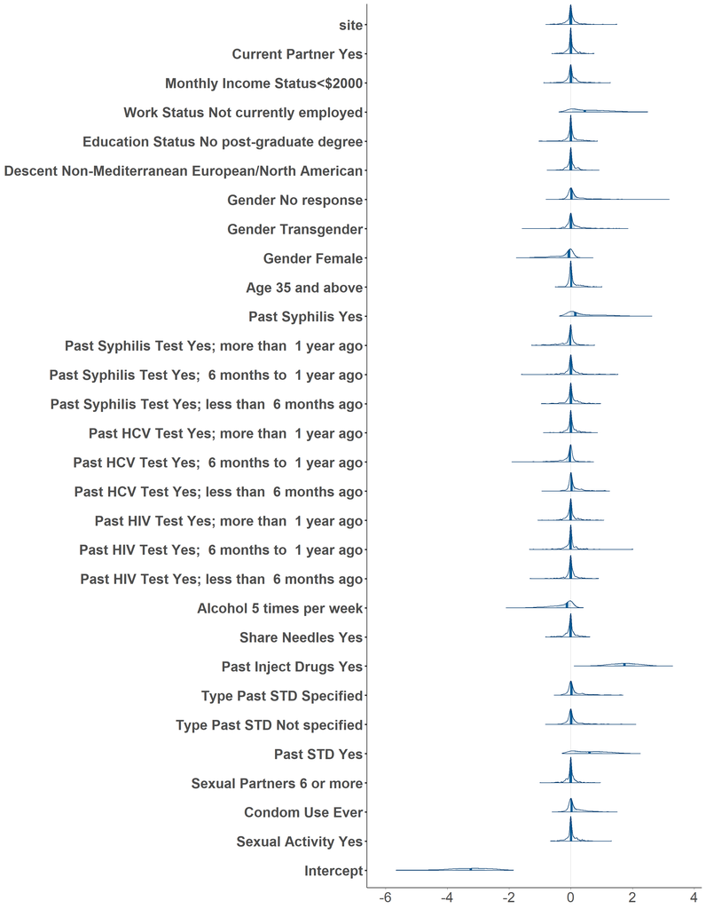

```r
ref_obj_hs<- model_imp_hs

prj_ref <- project(
  ref_obj_hs,
  verbose = F,
  predictor_terms = xvar
  )

# turn into matrix
prj_mat <- as.matrix(prj_ref)

# extract and clean the variable names

col <- colnames(prj_mat)

new_col<- str_replace_all(col, "(b_|\\d+-)| CAD", "") %>%
  str_replace_all("(?<!\\b(?:HCV|HIV|STD|CAD))(?<=\\w)(?=[A-Z])|(?<=\\D)(?=\\d)", " ") %>%
  str_replace_all(" 2; 000", "2000") %>%
  str_replace_all("H I V", "HIV") %>%
  str_replace_all("H C V", "HCV") %>%
  str_replace_all("S T D", "STD")

# to see the posterior distribution of each beta coefficient
mcmc_imp <- mcmc_areas(prj_mat)+
  scale_y_discrete(label= new_col)+ # add new column names
  xaxis_text(size= 20)+
  yaxis_text(size = 20)

mcmc_imp
```

**Y=HCV**

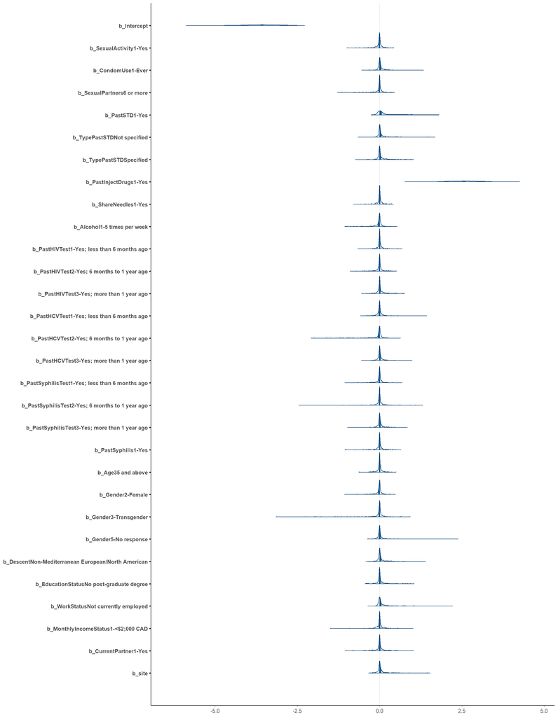

```r
ref_obj_hcv<- model_imp_hcv

prj_ref2 <- project(
  ref_obj_hcv,
  verbose = F,
  predictor_terms = xvar
  )

prj_predict2 <- proj_predict(prj_ref2)

# turn into matrix
prj_mat2 <- as.matrix(prj_ref2)

# to see the posterior distribution of each beta coefficient
mcmc_imp2 <- mcmc_areas(prj_mat2)
mcmc_imp2
```

Posteriors are similar

**Y=HIV/S**

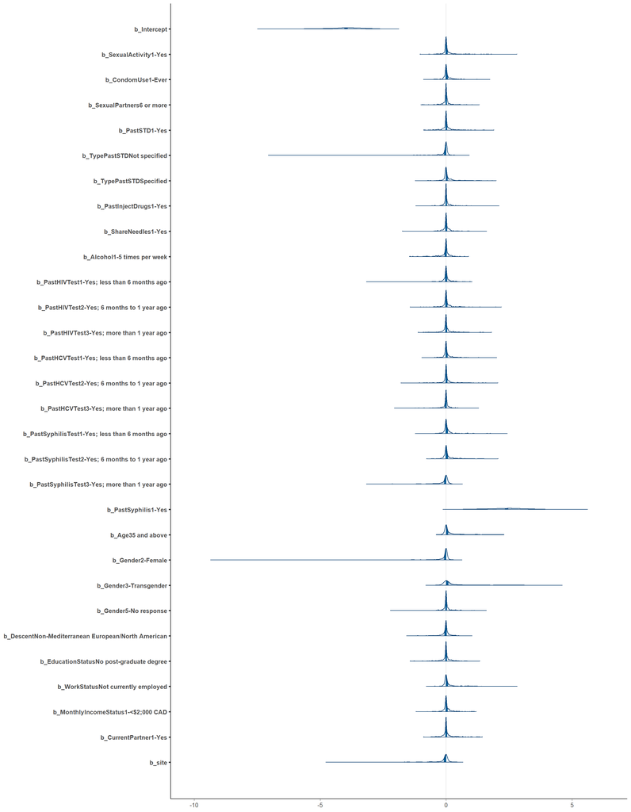

```r
ref_obj_hiv_s<- model_imp_hiv_s

prj_ref3 <- project(
  ref_obj_hiv_s,
  verbose = F,
  predictor_terms = xvar
  )

prj_predict3 <- proj_predict(prj_ref3)

# turn into matrix
prj_mat3 <- as.matrix(prj_ref3)

# to see the posterior distribution of each beta coefficient
mcmc_imp3 <- mcmc_areas(prj_mat3)
mcmc_imp3
```

posteriors are different

**CC**

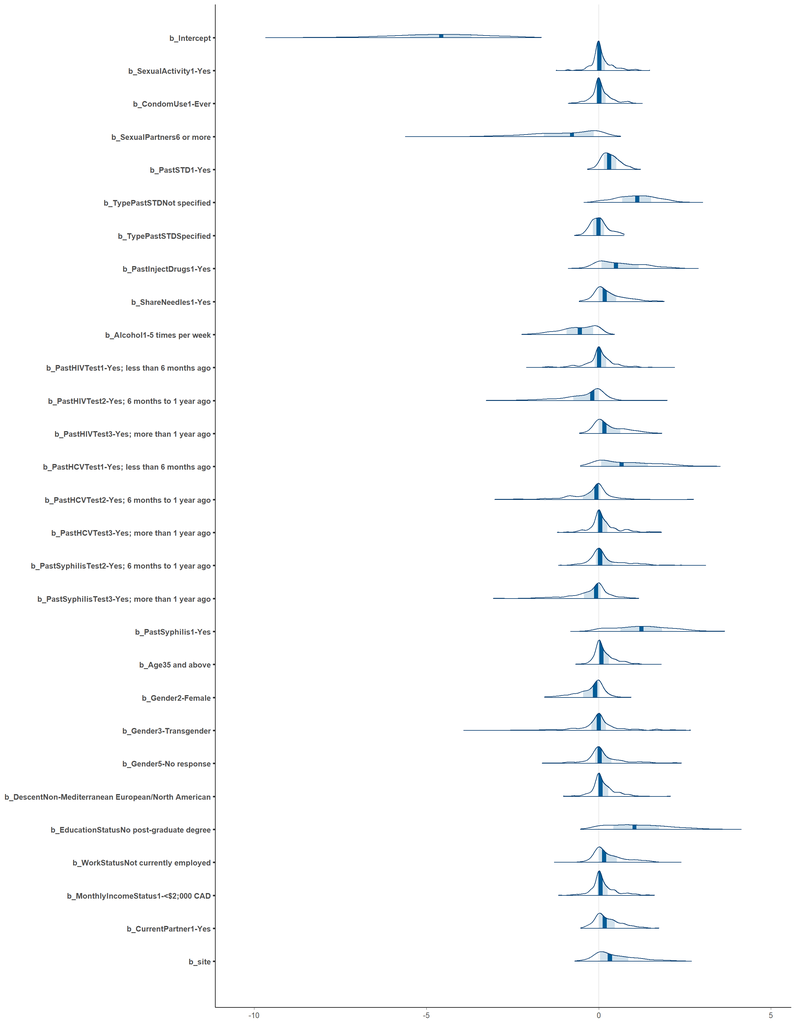

```r
ref_obj_hs<- model_hs_cc

prj_ref <- project(
  ref_obj_hs,
  verbose = F,
  predictor_terms = xvar
  )


# turn into matrix
prj_mat <- as.matrix(prj_ref)

# to see the posterior distribution of each beta coefficient
mcmc_cc <- mcmc_areas(prj_mat)
mcmc_cc
```

### Variable selection

Using 5 fold validation only and set search to 10 max

**Y=STBBI**

```r
cv_fits_imp <- run_cvfun(
  model_imp_hs  # 5k is default
)

# Final cv_varsel() run:
model_imp_nk <- cv_varsel(
  model_imp_hs,
  cv_method = "kfold",
  cv_fits = cv_fits_imp,
  method = "L1",
  nterms_max = 10,
  verbose = F
)

model_imp_nk
```

```
Family: binomial
Link function: logit

Formula: stbbi.pos ~ SexualActivity + CondomUse + SexualPartners + PastSTD +
    TypePastSTD + PastInjectDrugs + ShareNeedles + Alcohol +
    PastHIVTest + PastHCVTest + PastSyphilisTest + PastSyphilis +
    Age + Gender + Descent + EducationStatus + WorkStatus + MonthlyIncomeStatus +
    CurrentPartner + site
Observations: 300
Projection method: traditional
CV method: K-fold CV with K = 5 and search included (i.e., fold-wise searches)
Search method: L1
Maximum submodel size for the search: 10
Number of projected draws in the search: 1 (from clustered projection)
Number of projected draws in the performance evaluation: 400
Argument `refit_prj`: TRUE

Submodel performance evaluation summary with `deltas = FALSE` and `cumulate = FALSE`:
 size    ranking_fulldata cv_proportions_diag elpd elpd.se elpd.diff
    0         (Intercept)                  NA -141    10.3   -19.409
    1     PastInjectDrugs                 1.0 -123    10.0    -1.028
    2             PastSTD                 0.4 -127    10.6    -5.308
    3          WorkStatus                 0.0 -124    10.3    -1.922
    4        PastSyphilis                 0.2 -122     9.8    -0.025
    5             Alcohol                 0.0 -121     9.6     1.086
    6         PastHCVTest                 0.0 -121     9.6     1.088
    7              Gender                 0.2 -121     9.7     0.563
    8 MonthlyIncomeStatus                 0.0 -121     9.7     0.401
    9           CondomUse                 0.2 -122     9.7     0.144
   10         TypePastSTD                 0.0 -122     9.8    -0.111
 elpd.diff.se
         5.60
         3.01
         2.23
         1.74
         1.36
         1.13
         0.93
         0.82
         0.73
         0.68
         0.51

Reference model performance evaluation summary with `deltas = FALSE`:
   elpd elpd.se
 -121.7     9.8
```

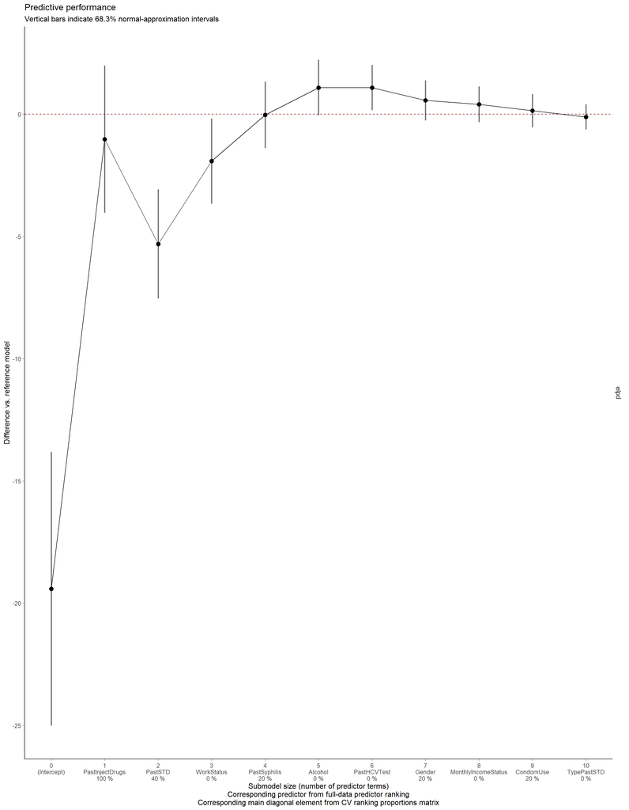

Submodels accuracy using rapid variable selection. Y axis values represent the DIFFERENCE in performance with the reference model. The percentage below each submodel represents the cross-validation ranking of predictors

```r
plot_k5 <- plot(model_imp_nk, stats = "elpd", deltas = TRUE)
plot_k5
```

**Y=HCV**

```r
cv_fits_imp <- run_cvfun(
  model_imp_hcv  # 5k is default
)

model_hcv <- cv_varsel(
  model_imp_hcv,
  cv_method = "kfold",
  cv_fits = cv_fits_imp,
  method = "L1",
  nterms_max = 10,
  verbose = F
)

model_hcv
```

```
Family: binomial
Link function: logit

Formula: hcv.pos ~ SexualActivity + CondomUse + SexualPartners + PastSTD +
    TypePastSTD + PastInjectDrugs + ShareNeedles + Alcohol +
    PastHIVTest + PastHCVTest + PastSyphilisTest + PastSyphilis +
    Age + Gender + Descent + EducationStatus + WorkStatus + MonthlyIncomeStatus +
    CurrentPartner + site
Observations: 300
Projection method: traditional
CV method: K-fold CV with K = 5 and search included (i.e., fold-wise searches)
Search method: L1
Maximum submodel size for the search: 10
Number of projected draws in the search: 1 (from clustered projection)
Number of projected draws in the performance evaluation: 400
Argument `refit_prj`: TRUE

Submodel performance evaluation summary with `deltas = FALSE` and `cumulate = FALSE`:
 size ranking_fulldata cv_proportions_diag elpd elpd.se elpd.diff elpd.diff.se
    0      (Intercept)                  NA -122    10.9   -23.542         6.62
    1  PastInjectDrugs                 1.0  -94     9.6     3.559         1.40
    2      TypePastSTD                 0.4  -98    10.0    -0.066         0.79
    3             site                 0.2  -98     9.9     0.074         0.66
    4          PastSTD                 0.0  -98     9.9     0.489         0.57
    5       WorkStatus                 0.2  -98     9.9     0.524         0.53
    6 PastSyphilisTest                 0.0  -97     9.9     0.694         0.54
    7      PastHCVTest                 0.2  -98    10.0     0.130         0.36
    8          Alcohol                 0.0  -98    10.0     0.164         0.36
    9   SexualActivity                 0.0  -98    10.0     0.140         0.31
   10      PastHIVTest                 0.2  -98    10.0    -0.024         0.30

Reference model performance evaluation summary with `deltas = FALSE`:
   elpd elpd.se
    -98      10
```

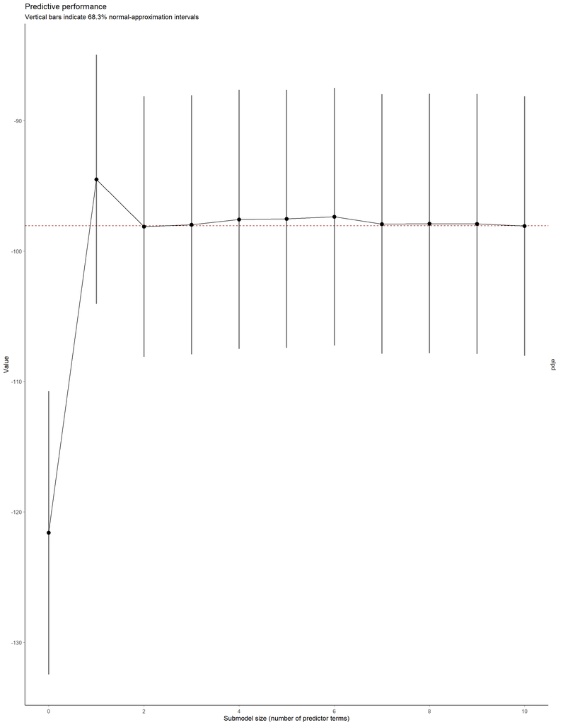

```r
plot(model_hcv, stats = "elpd", ranking_nterms_max = NA)
```

**Y=HIV/S**

```r
cv_fits_imp <- run_cvfun(
  model_imp_hiv_s  # 5k is default
)

model_hiv_s <- cv_varsel(
  model_imp_hiv_s,
  cv_method = "kfold",
  cv_fits = cv_fits_imp,
  method = "L1",
  nterms_max = 10,
  verbose = FALSE, # remove the text
)

model_hiv_s
```

```
Family: binomial
Link function: logit

Formula: hiv_s_pos ~ SexualActivity + CondomUse + SexualPartners + PastSTD +
    TypePastSTD + PastInjectDrugs + ShareNeedles + Alcohol +
    PastHIVTest + PastHCVTest + PastSyphilisTest + PastSyphilis +
    Age + Gender + Descent + EducationStatus + WorkStatus + MonthlyIncomeStatus +
    CurrentPartner + site
Observations: 300
Projection method: traditional
CV method: K-fold CV with K = 5 and search included (i.e., fold-wise searches)
Search method: L1
Maximum submodel size for the search: 10
Number of projected draws in the search: 1 (from clustered projection)
Number of projected draws in the performance evaluation: 400
Argument `refit_prj`: TRUE

Submodel performance evaluation summary with `deltas = FALSE` and `cumulate = FALSE`:
 size    ranking_fulldata cv_proportions_diag elpd elpd.se elpd.diff
    0         (Intercept)                  NA  -60    11.1    -12.28
    1        PastSyphilis                 1.0  -49     9.4     -0.91
    2    PastSyphilisTest                 1.0  -49     9.4     -0.65
    3              Gender                 0.2  -49     9.5     -0.78
    4         TypePastSTD                 0.6  -49     9.5     -0.80
    5                site                 0.0  -49     9.5     -1.04
    6                 Age                 0.0  -49     9.5     -0.96
    7 MonthlyIncomeStatus                 0.2  -49     9.4     -0.89
    8          WorkStatus                 0.0  -49     9.4     -0.77
    9         PastHCVTest                 0.0  -49     9.4     -0.78
   10           CondomUse                 0.0  -49     9.4     -0.63
 elpd.diff.se
         5.14
         0.84
         0.61
         0.53
         0.55
         0.57
         0.58
         0.56
         0.48
         0.42
         0.37

Reference model performance evaluation summary with `deltas = FALSE`:
   elpd elpd.se
  -48.0     9.2
```

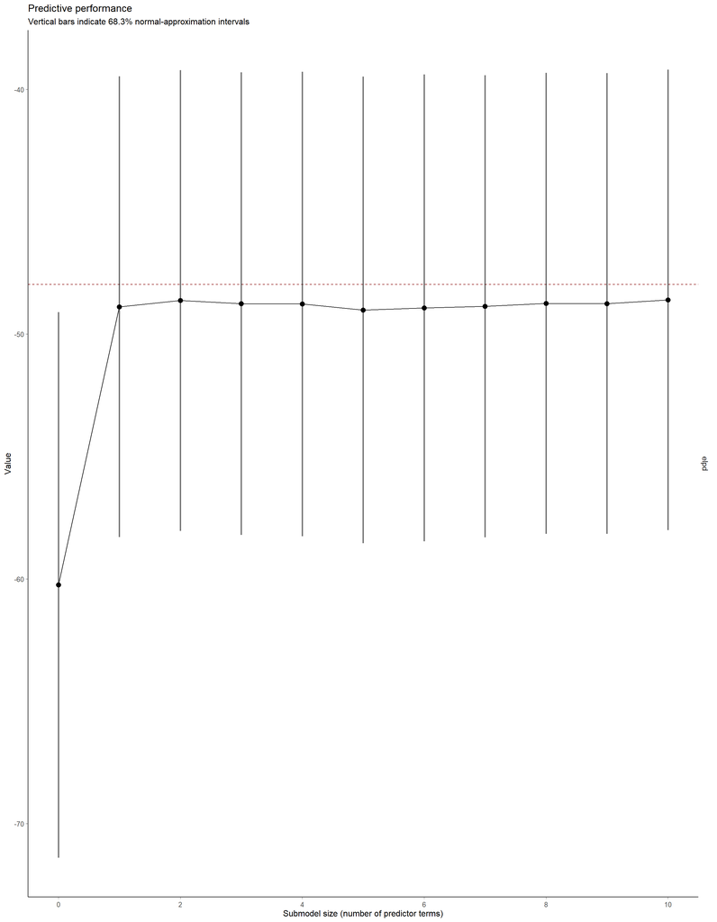

```r
plot(model_hiv_s, stats = "elpd", ranking_nterms_max = NA)
```

**CC**

```r
cv_fits_imp <- run_cvfun(
  model_hs_cc  # 5k is default
)


model_cc<- cv_varsel(
  model_hs_cc,
  cv_method = "kfold",
  cv_fits = cv_fits_imp,
  method = "L1",
  nterms_max = 10, # faster variable selection
  verbose = FALSE, # remove interactive text
)

model_cc
```

```
Family: binomial
Link function: logit

Formula: stbbi.pos ~ SexualActivity + CondomUse + SexualPartners + PastSTD +
    TypePastSTD + PastInjectDrugs + ShareNeedles + Alcohol +
    PastHIVTest + PastHCVTest + PastSyphilisTest + PastSyphilis +
    Age + Gender + Descent + EducationStatus + WorkStatus + MonthlyIncomeStatus +
    CurrentPartner + site
Observations: 242
Projection method: traditional
CV method: K-fold CV with K = 5 and search included (i.e., fold-wise searches)
Search method: L1
Maximum submodel size for the search: 10
Number of projected draws in the search: 1 (from clustered projection)
Number of projected draws in the performance evaluation: 400
Argument `refit_prj`: TRUE

Submodel performance evaluation summary with `deltas = FALSE` and `cumulate = FALSE`:
 size ranking_fulldata cv_proportions_diag elpd elpd.se elpd.diff elpd.diff.se
    0      (Intercept)                  NA -102     9.7   -14.835          5.4
    1      TypePastSTD                 0.6 -100     9.8   -12.042          4.2
    2  PastInjectDrugs                 0.8  -93     9.7    -5.288          3.6
    3          Alcohol                 0.4  -91     9.7    -3.888          3.3
    4  EducationStatus                 0.2  -89     9.3    -1.387          3.6
    5     ShareNeedles                 0.2  -91     9.5    -3.272          2.9
    6     PastSyphilis                 0.4  -89     9.1    -1.581          2.5
    7             site                 0.0  -87     9.1     0.074          1.9
    8      PastHCVTest                 0.0  -88     9.1    -0.170          1.7
    9       WorkStatus                 0.0  -88     9.2    -0.509          1.5
   10   SexualPartners                 0.0  -88     9.2    -0.390          1.3

Reference model performance evaluation summary with `deltas = FALSE`:
   elpd elpd.se
  -87.5     9.2
```

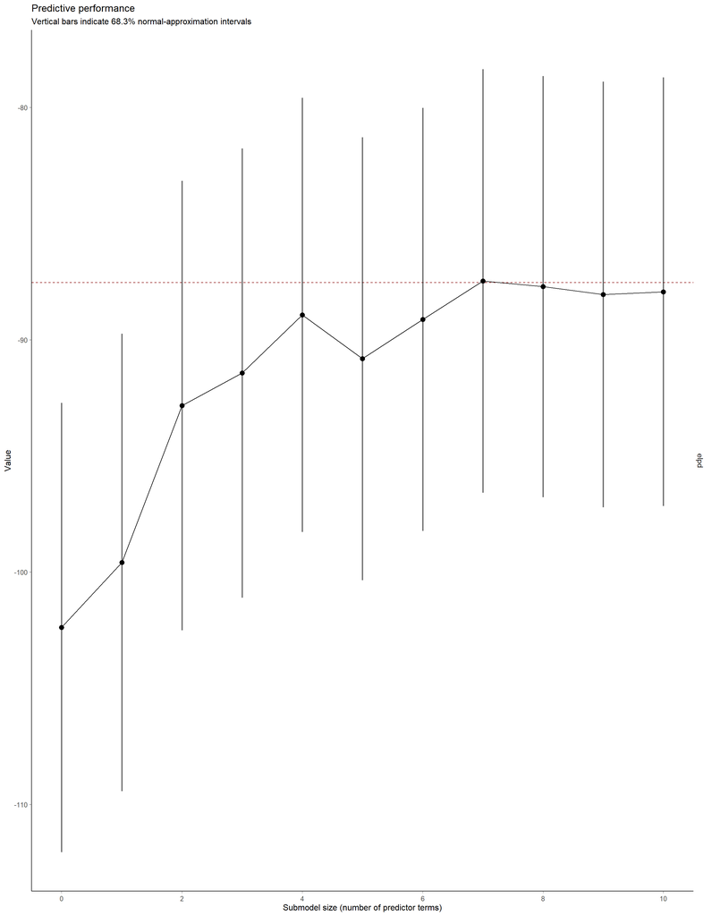

```r
plot(model_cc, stats = "elpd", ranking_nterms_max = NA)  #no ranking based on cross-validation because no cross-validation in this variable selection
```

### Cross-validation results

**Y=STBBI**

```r
ranking_imp <- ranking(model_imp_nk)
```

The predictors are ranked in the following order: PastInjectDrugs, PastSTD, WorkStatus, PastSyphilis, Alcohol, PastHCVTest, Gender, MonthlyIncomeStatus, CondomUse, TypePastSTD

**Y=HCV**

```r
ranking_hcv <- ranking(model_hcv)
ranking_hcv[["fulldata"]]
```

```
 [1] "PastInjectDrugs"  "TypePastSTD"      "site"             "PastSTD"
 [5] "WorkStatus"       "PastSyphilisTest" "PastHCVTest"      "Alcohol"
 [9] "SexualActivity"   "PastHIVTest"
```

**Y=HIV/S**

```r
ranking_hiv_s  <- ranking(model_hiv_s)
ranking_hiv_s[["fulldata"]]
```

```
 [1] "PastSyphilis"        "PastSyphilisTest"    "Gender"
 [4] "TypePastSTD"         "site"                "Age"
 [7] "MonthlyIncomeStatus" "WorkStatus"          "PastHCVTest"
[10] "CondomUse"
```

**CC**

```r
ranking1 <- ranking(model_cc)
ranking1[["fulldata"]]
```

```
 [1] "TypePastSTD"     "PastInjectDrugs" "Alcohol"         "EducationStatus"
 [5] "ShareNeedles"    "PastSyphilis"    "site"            "PastHCVTest"
 [9] "WorkStatus"      "SexualPartners"
```

### Select model

Will examine all the different sections with the same number of models

**Y=STBBI**

```r
size <- suggest_size(model_imp_nk, stat = "elpd")


predictors_final_imp <- head(ranking_imp[["fulldata"]], 9)
```

The suggested size for the model is 1 with the predictors in the following order PastInjectDrugs, PastSTD, WorkStatus, PastSyphilis, Alcohol, PastHCVTest, Gender, MonthlyIncomeStatus, CondomUse

**Y=HCV**

```r
size2 <- suggest_size(model_hcv, stat = "elpd")


predictors_hcv<- head(ranking_hcv[["fulldata"]], 9)
predictors_hcv
```

```
[1] "PastInjectDrugs"  "TypePastSTD"      "site"             "PastSTD"
[5] "WorkStatus"       "PastSyphilisTest" "PastHCVTest"      "Alcohol"
[9] "SexualActivity"
```

The suggested size for the model is 1

**Y=HIV/S**

```r
size3 <- suggest_size(model_hiv_s, stat = "elpd")


predictors_hiv_s<- head(ranking_hiv_s[["fulldata"]], 9)
predictors_hiv_s
```

```
[1] "PastSyphilis"        "PastSyphilisTest"    "Gender"
[4] "TypePastSTD"         "site"                "Age"
[7] "MonthlyIncomeStatus" "WorkStatus"          "PastHCVTest"
```

The suggested size for the model is NA

**CC**

```r
predictors_final_cc <- head(ranking1[["fulldata"]], 9) # same size as for imputed dataset
predictors_final_cc
```

```
[1] "TypePastSTD"     "PastInjectDrugs" "Alcohol"         "EducationStatus"
[5] "ShareNeedles"    "PastSyphilis"    "site"            "PastHCVTest"
[9] "WorkStatus"
```

## Y=STBBI

```r
# use the submodel function
s1 <- submodels_train(model_imp_hs, predictor_ranking = predictors_final_imp, new_data = training_set_imp)
# measure sensitivity, specificity and AUC using cindy's formula for all models
s1
```

```
[[1]]
 Family: bernoulli
  Links: mu = logit
Formula: stbbi.pos ~ PastInjectDrugs
   Data: training_set_imp (Number of observations: 300)
  Draws: 4 chains, each with iter = 2000; warmup = 1000; thin = 1;
         total post-warmup draws = 4000

Population-Level Effects:
                     Estimate Est.Error l-95% CI u-95% CI Rhat Bulk_ESS
Intercept               -2.44      0.26    -2.98    -1.96 1.00     2157
PastInjectDrugs1MYes     1.87      0.33     1.23     2.51 1.00     3438
                     Tail_ESS
Intercept                2452
PastInjectDrugs1MYes     3171

Draws were sampled using sampling(NUTS). For each parameter, Bulk_ESS
and Tail_ESS are effective sample size measures, and Rhat is the potential
scale reduction factor on split chains (at convergence, Rhat = 1).

[[2]]
 Family: bernoulli
  Links: mu = logit
Formula: stbbi.pos ~ PastInjectDrugs + PastSTD
   Data: training_set_imp (Number of observations: 300)
  Draws: 4 chains, each with iter = 2000; warmup = 1000; thin = 1;
         total post-warmup draws = 4000

Population-Level Effects:
                     Estimate Est.Error l-95% CI u-95% CI Rhat Bulk_ESS
Intercept               -2.93      0.36    -3.68    -2.24 1.00     2467
PastInjectDrugs1MYes     1.94      0.34     1.28     2.62 1.00     4100
PastSTD1MYes             0.88      0.39     0.02     1.60 1.00     2070
                     Tail_ESS
Intercept                2510
PastInjectDrugs1MYes     3493
PastSTD1MYes              983

Draws were sampled using sampling(NUTS). For each parameter, Bulk_ESS
and Tail_ESS are effective sample size measures, and Rhat is the potential
```

[output cut: 300 more lines]

```
PastSyphilis1MYes                                  1.66 1.00     2139     3255
Age35andabove                                      0.63 1.00     3552     3181
Gender2MFemale                                     0.14 1.00     2026     3332
Gender3MTransgender                                0.99 1.00     3495     2606
Gender5MNoresponse                                 1.49 1.00     2959     3103
DescentNonMMediterraneanEuropeanDNorthAmerican     0.44 1.00     4202     3651
EducationStatusNopostMgraduatedegree               0.56 1.00     4536     3514
WorkStatusNotcurrentlyemployed                     1.78 1.00     1573     3140
MonthlyIncomeStatus1M<$2;000CAD                    0.61 1.00     3774     3623
CurrentPartner1MYes                                0.43 1.00     4373     3438
site                                               0.61 1.00     3783     3062

Draws were sampled using sampling(NUTS). For each parameter, Bulk_ESS
and Tail_ESS are effective sample size measures, and Rhat is the potential
scale reduction factor on split chains (at convergence, Rhat = 1).
```

```r
colnames <- c(paste0("model",1:length(predictors_final_imp)), "ref")

s1.sens<- mult.sens(training_set_imp$stbbi.pos, s1) # 2000 iter default
s1.sens
```

```
   rowname       Q50      Q5.5     Q94.5      Q2.5     Q97.5
1   model1 0.8461538 0.7975709 0.8906883 0.7894737 0.8987854
2   model2 0.8502024 0.8016194 0.8947368 0.7935223 0.9028340
3   model3 0.8542510 0.8097166 0.8947368 0.7975709 0.9028340
4   model4 0.8582996 0.8097166 0.8947368 0.8016194 0.9028340
5   model5 0.8582996 0.8097166 0.8987854 0.7975709 0.9068826
6   model6 0.8542510 0.8097166 0.8947368 0.8015182 0.9028340
7   model7 0.8582996 0.8178138 0.8987854 0.8056680 0.9068826
8   model8 0.8582996 0.8137652 0.8987854 0.8056680 0.9068826
9   model9 0.8582996 0.8137652 0.8987854 0.8016194 0.9068826
10     ref 0.8542510 0.8056680 0.8987854 0.7975709 0.9068826
```

```r
s1.spec<- mult.spec(training_set_imp$stbbi.pos, s1) # 2000 iter default
s1.spec
```

```
   rowname       Q50      Q5.5     Q94.5      Q2.5     Q97.5
1   model1 0.2830189 0.1698113 0.3962264 0.1509434 0.4150943
2   model2 0.3207547 0.2075472 0.4339623 0.1698113 0.4528302
3   model3 0.3207547 0.2075472 0.4339623 0.1886792 0.4716981
4   model4 0.3207547 0.2264151 0.4528302 0.1886792 0.4716981
5   model5 0.3396226 0.2264151 0.4528302 0.1886792 0.4716981
6   model6 0.3396226 0.2264151 0.4528302 0.2075472 0.4716981
7   model7 0.3584906 0.2264151 0.4716981 0.2075472 0.4905660
8   model8 0.3396226 0.2442453 0.4528302 0.2075472 0.4905660
9   model9 0.3584906 0.2264151 0.4716981 0.2075472 0.4905660
10     ref 0.3207547 0.2075472 0.4528302 0.1886792 0.4716981
```

```r
s1.auc<- mult.auc(training_set_imp$stbbi.pos, s1)
s1.auc
```

```
   rowname       Q50      Q5.5     Q94.5      Q2.5     Q97.5
1   model1 0.7289359 0.7289359 0.7289359 0.7289359 0.7289359
2   model2 0.7830953 0.7830953 0.7830953 0.7284776 0.7830953
3   model3 0.8054007 0.7996715 0.8081506 0.7590329 0.8081506
4   model4 0.8193033 0.8019208 0.8272095 0.7946681 0.8274387
5   model5 0.8229318 0.8020736 0.8340081 0.7948151 0.8346956
6   model6 0.8193415 0.7979486 0.8319498 0.7883164 0.8337808
7   model7 0.8264075 0.8030326 0.8401574 0.7935586 0.8426018
8   model8 0.8247651 0.7999729 0.8397838 0.7893572 0.8422198
9   model9 0.8282026 0.8015388 0.8442441 0.7926820 0.8469196
10     ref 0.8101749 0.7737293 0.8323276 0.7617313 0.8363800
```

```r
submodels_perf <- bind_rows(s1.sens, s1.spec, s1.auc) %>%
  rename(model = rowname) %>%
  mutate(performance = rep(c("sensitivity", "specificity", "auc"), each=length(colnames)),
         data = "training", outcome="STBBI")
```

The specificity is much lower than the sensitivity. We will also add the reference model values. models 3 to 9 are above 0.80 (considered an acceptable AUC)

## Y=HCV

```r
s2_train<- submodels_train2(model_imp_hcv, predictor_ranking = predictors_hcv, new_data = training_set_hcv, outcome = "hcv.pos")
s2.sens<- mult.sens(training_set_hcv$hcv.pos, s2_train) # 2000 iter default

s2.spec<- mult.spec(training_set_hcv$hcv.pos, s2_train) # 2000 iter default2

s2.auc<- mult.auc(training_set_hcv$hcv.pos, s2_train) # 2000 iter default

submodels_perf2 <- bind_rows(s2.sens, s2.spec, s2.auc) %>%
  rename(model = rowname) %>%
  mutate(performance = rep(c("sensitivity", "specificity", "auc"), each=length(colnames)),
         data = "training", outcome="HCV")
```

## Y=HIV_S

```r
s3_train<- submodels_train2(model_imp_hiv_s, predictor_ranking = predictors_hiv_s, new_data = training_set_hiv_s,  outcome = "hiv_s_pos")
s3.sens<- mult.sens(training_set_hiv_s$hiv_s_pos, s3_train) # 2000 iter default

s3.spec<- mult.spec(training_set_hiv_s$hiv_s_pos, s3_train) # 2000 iter default

s3.auc<- mult.auc(training_set_hiv_s$hiv_s_pos, s3_train) # 2000 iter default


submodels_perf3 <- bind_rows(s3.sens, s3.spec, s3.auc) %>%
  rename(model = rowname) %>%
  mutate(performance = rep(c("sensitivity", "specificity", "auc"), each=length(colnames)),
         data = "training", outcome="HIV/S")
```

## CC

```r
# use the submodel function
submodels_cc_train<- submodels_train(model_hs_cc, predictor_ranking = predictors_final_cc, new_data = training_set)
submodels.sens.cc<- mult.sens(training_set$stbbi.pos, submodels_cc_train) # 2000 iter default


submodels.spec.cc<- mult.spec(training_set$stbbi.pos, submodels_cc_train) # 2000 iter default


submodels.auc.cc<- mult.auc(training_set$stbbi.pos, submodels_cc_train)

submodels_perf_cc <- bind_rows(submodels.sens.cc, submodels.spec.cc, submodels.auc.cc) %>%
  rename(model = rowname) %>%
  mutate(performance = rep(c("sensitivity", "specificity", "auc"), each=length(colnames)),
         data = "training", outcome="cc")
```

Combine all values and save to plot later

```r
submodels_perf_fin <- bind_rows(submodels_perf, submodels_perf2, submodels_perf3, submodels_perf_cc)
```

#### Testing data

We fit our submodels with testing data and extract the sensitivity, specificity and AUC

```r
s1_test<- submodels_test(s1, new_data = testing_set_imp)

# measure sensitivity, specificity and AUC using cindy's formula for all models
s1_test
```

```
[[1]]
 Family: bernoulli
  Links: mu = logit
Formula: stbbi.pos ~ PastInjectDrugs
   Data: training_set_imp (Number of observations: 300)
  Draws: 4 chains, each with iter = 2000; warmup = 1000; thin = 1;
         total post-warmup draws = 4000

Population-Level Effects:
                     Estimate Est.Error l-95% CI u-95% CI Rhat Bulk_ESS
Intercept               -2.44      0.26    -2.98    -1.96 1.00     2157
PastInjectDrugs1MYes     1.87      0.33     1.23     2.51 1.00     3438
                     Tail_ESS
Intercept                2452
PastInjectDrugs1MYes     3171

Draws were sampled using sampling(NUTS). For each parameter, Bulk_ESS
and Tail_ESS are effective sample size measures, and Rhat is the potential
scale reduction factor on split chains (at convergence, Rhat = 1).

[[2]]
 Family: bernoulli
  Links: mu = logit
Formula: stbbi.pos ~ PastInjectDrugs + PastSTD
   Data: training_set_imp (Number of observations: 300)
  Draws: 4 chains, each with iter = 2000; warmup = 1000; thin = 1;
         total post-warmup draws = 4000

Population-Level Effects:
                     Estimate Est.Error l-95% CI u-95% CI Rhat Bulk_ESS
Intercept               -2.93      0.36    -3.68    -2.24 1.00     2467
PastInjectDrugs1MYes     1.94      0.34     1.28     2.62 1.00     4100
PastSTD1MYes             0.88      0.39     0.02     1.60 1.00     2070
                     Tail_ESS
Intercept                2510
PastInjectDrugs1MYes     3493
PastSTD1MYes              983

Draws were sampled using sampling(NUTS). For each parameter, Bulk_ESS
and Tail_ESS are effective sample size measures, and Rhat is the potential
```

[output cut: 300 more lines]

```
PastSyphilis1MYes                                  1.66 1.00     2139     3255
Age35andabove                                      0.63 1.00     3552     3181
Gender2MFemale                                     0.14 1.00     2026     3332
Gender3MTransgender                                0.99 1.00     3495     2606
Gender5MNoresponse                                 1.49 1.00     2959     3103
DescentNonMMediterraneanEuropeanDNorthAmerican     0.44 1.00     4202     3651
EducationStatusNopostMgraduatedegree               0.56 1.00     4536     3514
WorkStatusNotcurrentlyemployed                     1.78 1.00     1573     3140
MonthlyIncomeStatus1M<$2;000CAD                    0.61 1.00     3774     3623
CurrentPartner1MYes                                0.43 1.00     4373     3438
site                                               0.61 1.00     3783     3062

Draws were sampled using sampling(NUTS). For each parameter, Bulk_ESS
and Tail_ESS are effective sample size measures, and Rhat is the potential
scale reduction factor on split chains (at convergence, Rhat = 1).
```

```r
s1.sens<- mult.sens(testing_set_imp$stbbi.pos, s1_test) # 2000 iter default
s1.sens
```

```
   rowname    Q50      Q5.5  Q94.5   Q2.5  Q97.5
1   model1 0.8500 0.7750000 0.9125 0.7500 0.9250
2   model2 0.8500 0.7750000 0.9125 0.7625 0.9250
3   model3 0.8500 0.7868125 0.9125 0.7625 0.9250
4   model4 0.8625 0.7875000 0.9125 0.7750 0.9250
5   model5 0.8625 0.7875000 0.9125 0.7750 0.9250
6   model6 0.8625 0.7875000 0.9125 0.7750 0.9250
7   model7 0.8625 0.8000000 0.9250 0.7750 0.9375
8   model8 0.8625 0.8000000 0.9250 0.7750 0.9250
9   model9 0.8625 0.8000000 0.9250 0.7750 0.9250
10     ref 0.8500 0.7875000 0.9125 0.7750 0.9250
```

```r
s1.spec<- mult.spec(testing_set_imp$stbbi.pos, s1_test) # 2000 iter default
s1.spec
```

```
   rowname  Q50 Q5.5 Q94.5 Q2.5 Q97.5
1   model1 0.35 0.15  0.50 0.15  0.55
2   model2 0.35 0.20  0.55 0.15  0.60
3   model3 0.35 0.15  0.55 0.15  0.55
4   model4 0.35 0.20  0.55 0.15  0.60
5   model5 0.35 0.20  0.55 0.15  0.60
6   model6 0.35 0.20  0.55 0.15  0.60
7   model7 0.35 0.20  0.55 0.15  0.60
8   model8 0.35 0.20  0.55 0.15  0.60
9   model9 0.35 0.20  0.55 0.15  0.60
10     ref 0.35 0.20  0.55 0.15  0.60
```

```r
s1.auc<- mult.auc(testing_set_imp$stbbi.pos, s1_test)
s1.auc
```

```
   rowname       Q50      Q5.5     Q94.5      Q2.5     Q97.5
1   model1 0.8125000 0.8125000 0.8125000 0.8125000 0.8125000
2   model2 0.8581250 0.8581250 0.8581250 0.7668750 0.8581250
3   model3 0.8425000 0.8018750 0.8587500 0.7918750 0.8587500
4   model4 0.8559375 0.8146875 0.8771875 0.8059375 0.8778125
5   model5 0.8618750 0.8250000 0.8812500 0.8131094 0.8831250
6   model6 0.8709375 0.8265281 0.9021875 0.8146875 0.9078125
7   model7 0.8671875 0.8196875 0.8996875 0.8053125 0.9053281
8   model8 0.8656250 0.8200000 0.9025000 0.8050000 0.9081406
9   model9 0.8615625 0.8153125 0.8965625 0.8015625 0.9028125
10     ref 0.8575000 0.7962156 0.9006250 0.7793750 0.9087500
```

```r
submodels_perf <- bind_rows(s1.sens, s1.spec, s1.auc) %>%
  rename(model = rowname) %>%
  mutate(performance = rep(c("sensitivity", "specificity", "auc"), each=length(colnames)),
         data = "testing", outcome="STBBI")
```

# Y=HCV

```r
s2_test<- submodels_test(s2_train, new_data = testing_set_hcv)


s2.sens<- mult.sens(testing_set_hcv$hcv.pos, s2_test) # 2000 iter default

s2.spec<- mult.spec(testing_set_hcv$hcv.pos, s2_test) # 2000 iter default2

s2.auc<- mult.auc(testing_set_hcv$hcv.pos, s2_test)

submodels_perf2 <- bind_rows(s2.sens, s2.spec, s2.auc) %>%
  rename(model = rowname) %>%
  mutate(performance = rep(c("sensitivity", "specificity", "auc"), each=length(colnames)),
         data = "testing", outcome="HCV")
```

## Y=HIV_S

```r
s3_test<- submodels_test(s3_train, new_data = testing_set_hiv_s)

s3.sens<- mult.sens(testing_set_hiv_s$hiv_s_pos, s3_test) # 2000 iter default

s3.spec<- mult.spec(testing_set_hiv_s$hiv_s_pos, s3_test) # 2000 iter default

s3.auc<- mult.auc(testing_set_hiv_s$hiv_s_pos, s3_test) # 2000 iter default


submodels_perf3 <- bind_rows(s3.sens, s3.spec, s3.auc) %>%
  rename(model = rowname) %>%
  mutate(performance = rep(c("sensitivity", "specificity", "auc"), each=length(colnames)),
         data = "testing", outcome="HIV/S")
```

Specificity remains very similar regardless of model size

```r
submodels_cc_test<- submodels_test(submodels_cc_train, new_data = testing_set)


submodels.sens.cc<- mult.sens(testing_set$stbbi.pos, submodels_cc_test) # 2000 iter default


submodels.spec.cc<- mult.spec(testing_set$stbbi.pos, submodels_cc_test) # 2000 iter default


submodels.auc.cc<- mult.auc(testing_set$stbbi.pos, submodels_cc_test)

submodels_perf4 <- bind_rows(submodels.sens.cc, submodels.spec.cc, submodels.auc.cc) %>%
  rename(model = rowname) %>%
  mutate(performance = rep(c("sensitivity", "specificity", "auc"), each=length(colnames)),
         data = "testing", outcome="cc")
```

Which submodel performs best?

```r
# combine
submodels_perf_fin <- bind_rows(submodels_perf_fin, submodels_perf, submodels_perf2, submodels_perf3, submodels_perf4)

#save

write.csv(submodels_perf_fin, "3_intermediate/projpred/submodels_performance_SA.csv", row.names = F)
```

## **Reference:**

Piironen J, Paasiniemi M, Catalina A, Weber F, Vehtari A (2023). “projpred: Projection Predictive Feature Selection.” R package version 2.8.0, https://mc-stan.org/projpred/.

See vignettes for more information